# Development records notebook

Pedro Ivo Guimarães

# Packages and global options

```r
library(tidyverse)
library(stringr)
library(ggforce)
library(cowplot)
library(RcppRoll)
source("~/proposal_prelimn/code/libraries_and_global_opts.R")
devtools::load_all(pkg = "~/lambdaPrimeR/")
```

# February

## 02-26-18

### Importing sequences

The most basic function of this app is importing a sequence file on FASTA format. The imported file can either be the *template* sequence or the *target* sequence. The target sequence is the DNA sequence of the gene of interest that will be inserted into the template sequence. We can create a basic function to import a DNA sequence with two derived functions, one for each type of input:

```r
read_sequence <- function(file, ...) {
  raw <- as_data_frame(read_file(file))

  df <-raw %>%
    separate_rows(value, sep = '\n>') %>%
    separate(value, into = c('header', 'seq'), sep = '\n', extra = 'merge') %>%
    mutate(
      seq = str_replace_all(seq, '\n', ''),
      header = str_replace(header, '>', ''),
      length = nchar(seq)
    )
}

template <- read_sequence("../data/puc19.fasta")
target <- read_sequence("../data/GFP sequence.fasta")
```

## 02-28-18

### Updating `read_sequence` function

An useful functionality of `read_sequence` would be simplifying the sequence header information by allowing the user provide a `header_structure` vector — containing the naming scheme of the sequence header — and `id_field` — the field that will be used as the seq id:

```r
read_sequence <- function(file, id_field = NULL, separator = NULL) {
  raw <- as_data_frame(read_file(file))

  df <- raw %>%
    separate_rows(value, sep = '\n>') %>%
    separate(value, into = c('header', 'seq'), sep = '\n', extra = 'merge') %>%
    mutate(
      seq = str_replace_all(seq, '\n', ''),
      header = str_replace(header, '>', ''),
      length = nchar(seq)
    )

  #Checking if optional parameters were passed
  if(is.null(id_field)) {
    id_field <- 'id'
  }
  if(is.null(separator)) {
    separator <- '\\|'
  }

  #Creating sequence id from seq header
  df <- df %>%
    separate(header, into = id_field, extra = 'drop', sep = separator)
}

template <- read_sequence("../data/puc19.fasta")
target <- read_sequence("../data/GFP sequence.fasta")
```

# March

## 03-01-18

### Update `read_sequence` to add `type` tag to sequences

The `read_sequence` function does not differentiate if the sequence object is a template or a target gene object, so I’ll update it again to import the DNA sequences and add a tag `template` or `target`:

```r
read_sequence <- function(file, input_type, id_field = NULL, separator = NULL) {
  raw <- as_data_frame(read_file(file))

  df <- raw %>%
    separate_rows(value, sep = '\n>') %>%
    separate(value, into = c('header', 'seq'), sep = '\n', extra = 'merge') %>%
    mutate(
      type = input_type,
      seq = str_replace_all(seq, '\n', ''),
      header = str_replace(header, '>', ''),
      length = nchar(seq)
    )

  #Checking if optional parameters were passed
  if(is.null(id_field)) {
    id_field <- 'id'
  }
  if(is.null(separator)) {
    separator <- '\\|'
  }

  #Creating sequence id from seq header
  df <- df %>%
    separate(header, into = id_field, remove = F, extra = 'drop', sep = separator)
}

template <- read_sequence("../data/puc19.fasta", input_type = 'template')
target <- read_sequence("../data/GFP sequence.fasta", input_type = 'target')
```

### Design primers for gene insertion

#### Extract template and target gene sequence overlaps for primer design

The simplest design case for Lambda PCR is the insertion of the target gene in a defined location in the destination plasmid. The first thing we need to do is write a function that will collect the extract the *n*-length flanking regions to the left and right of the insertion site and store as the template-overlaping tails of the primers.

```r
# insertion_coordinate <- 1500
# ins_flank_length <- 20
# target_primer_length <- 15

#Functions to extract flanking sequences from insertion site:
get_overlaps <- function(seq_object, position=NULL, length=NULL) {
  #Initialize empty overlap object
  overlaps <- tibble(
    id = character(),
    type = character(),
    origin = character(),
    seq = character()
  )

  #Checking what type of object was passed to function:
  if(seq_object$type == 'template') {
    #Using default overlap length of 20 if not provided:
    overlap_length <- ifelse(is.null(length), 20, length)
    #Extracting overlaps
    overlap_left <- substr(seq_object$seq, (position-overlap_length), position)
    overlap_right <- substr(seq_object$seq, (position+1), (overlap_length+position+1))
    #Populating overlap object:
    overlaps <- overlaps %>%
      add_row(id = 'left', type = 'overlap', origin = 'template', seq = overlap_left) %>%
      add_row(id = 'right', type = 'overlap', origin = 'template', seq = overlap_right)
  } else {
    #Using default overlap length of 20 if not provided:
    overlap_length <- ifelse(is.null(length), 15, length)
    #Extracting overlaps
    overlap_left <- substr(seq_object$seq, 1, overlap_length)
    overlap_right <- substr(seq_object$seq, seq_object$length-overlap_length, seq_object$length)
    #Populating overlap object:
    overlaps <- overlaps %>%
      add_row(id = 'left', type = 'overlap', origin = 'target', seq = overlap_left) %>%
      add_row(id = 'right', type = 'overlap', origin = 'target', seq = overlap_right)
  }
}

overlaps_template <- get_overlaps(template, position = 1500)
overlaps_target <- get_overlaps(target)
```

#### Complement and reverse complement functions:

```r
complement <- function(sequence) {
  seq <- toupper(sequence)
  complement <- chartr('ATCG', 'TAGC', seq)
}

reverse_complement <- function(sequence) {
  complement <- complement(sequence)
  revcomp <- stringi::stri_reverse(complement)
}
```

#### Correct primer orientations

Primer design for LambdaPCR is tricky because there are special rules that need to be followed regarding the primer tails. I had to use colored markers to understand what to do:

```r
knitr::include_graphics("~/Downloads/Lambapcr_primer_rules.jpg")
knitr::include_graphics("~/Desktop/lambdapcr_overview.png")
```

[output not shown]

So, in order to design the primers for the first PCR of LambdaPCR, we have to use the following rules:

- Forward primer: template left overlap + target left overlap, 5’-3’ orientation
- Reverser primer: complement of target right overlap + complement of template right overlap, 5’-3’ orientation

Now that we have the overlaps for both the template and the target sequences, we can create our first LambdaPCR primer pair:

```r
create_primers <- function(overlaps_target, overlaps_template) {
  overlaps <- bind_rows(overlaps_target, overlaps_template)

  primers <- overlaps %>%
    spread(origin, seq) %>%
    select(-type) %>%
    mutate(
      seq = case_when(
        id == 'left' ~ paste(tolower(template),
                             target,
                             sep = ''),
        id == 'right' ~ paste(tolower(reverse_complement(template)),
                              reverse_complement(target),
                              sep = ''
                              )
      )
    ) %>%
    mutate(id = case_when(
      id == 'left' ~ gsub('left', 'forward', id),
      id == 'right' ~ gsub('right', 'reverse', id)
    )) %>%
    mutate(type = 'primer') %>%
    select(-target, -template)
}

primers <- create_primers(overlaps_target, overlaps_template)
```

## 03/08/18

### `lambdaPrimer` flowchart

```r
library(DiagrammeR)

grViz("
  digraph lambdaPrimeR_dataflow {
    rankdir='LR';
    # splines='ortho';
    #internal object nodes:
    node [shape = circle]
    input; overlaps; primers; score

    #Input and output nodes
    node [shape = box]
    target; template; ins_position; report

    #Function nodes:
    node [shape = plaintext]
    read_sequences; get_overlaps; create_primer; melt_temp;
    hairpin_prob; primer_score; rank_primers; mutate_primer;
    report_best_primers

    #Edges:
    target -> read_sequences; template -> read_sequences;
    read_sequences -> input; input -> get_overlaps;
    ins_position -> get_overlaps; get_overlaps -> overlaps;
    overlaps -> create_primer; create_primer -> primers;
    primers -> report_best_primers; report_best_primers -> report

    subgraph cluster_ga {
      primers -> melt_temp; primers -> hairpin_prob;
      hairpin_prob -> primer_score; melt_temp -> primer_score;
      primer_score -> score; score -> rank_primers;
      rank_primers -> mutate_primer; mutate_primer -> primers;
      label = 'Genetic algorithm'
    }

  }
")
```

## 03/09/2018

### Melting temperature calculation with MELTING tool

Today I am learning how to use the [MELTING](https://www.ebi.ac.uk/biomodels/tools/melting/) tool to calculate the melting temperature of primers. Accoring to the documenation, the following options are mandatory:

```
Mandatory options :

-S [sequence]
    Nucleic acid sequence, mandatory. The sens of this sequence must be 5'-3'.


-C [complementary sequence]
    Nucleic acid complementary sequence, mandatory only if there is inosine bases
    or azobenznes in the sequence entered with the opton -S. The sens of this
    sequence must be 3'-5''.

-E [agent1=concentration1:agent2=concentration2]
    Different agent concentrations in the solution. The agents can be cations
    (Na, K, Tris, Mg for Na+, K+, Tris+ and Mg2+), dNTP or other agents
    (DMSO, formamide). The concentrations must be in Mol/L but there are some
    exceptions : DMSO is a percentage, formamide is a percentage if the method
    lincorr is chosen and in Mol/L if the method bla96 is chosen. At least one
    cation concentration is mandatory, the other agents are optional. See the
    documentation for the concentration limits. It depends on the used correction.

-P [nucleotide concentration]
    Concentration in mol/L of the nucleic acid strand in excess, mandatory.

-H [hybridization]
    Type of hybridization, mandatory. Four types of hybridization are allowed:
    dnadna (DNA duplex), rnarna (RNA duplex), dnarna or rnadna (hybrid DNA/RNA)
    and mrnarna or rnamrna (2-o-methyl RNA/ RNA). The type of hybridization
    defines the kind of the sequence and its complementary.
        Ex : dnarna = the sequence (entered with the option -S) is a DNA sequence
        and its complementary (entered with the option -C) is a RNA sequence.
        Ex : rnadna = the sequence (entered with the option -S) is a RNA sequence
        and its complementary (entered with the option -C) is a DNA sequence
```

We can use the following command to calculate the melting temperature of a DNA-DNA hybridization:

```bash
/Users/pedro_work/MELTING5.1.1/executable/melting -S ATGGTGAGCAAGGGC -H dnadna
-P 1e-7 -E Mg=1
```

```
SEVERE :
 To compute, MELTING need at less the hybridization type (option -H), the nucleic acid concentration (option -P) and the sequence (option -S). If there are inosine bases in the sequence, a complementary sequence is required (option-C).
```

```
/var/folders/ds/q3p1l9wn2_v1tjzy1jvtvgr00000gp/T/RtmpOpQeCC/chunk-code-5623f8f01cb.txt: line 2: -P: command not found
```

### Integrating MELTING and R

To test the MELTING tool, I am going to use the `lambdaPrimeR` test primer sequences. The test primers are designed using the GFP gene sequence as target and the pUC19 plasmid sequence as template. The insertion coordinate is 1500.

```r
#Input sequences:
target <- system.file('extdata', 'GFP sequence.fasta', package = 'lambdaPrimeR')
template <- system.file('extdata', 'puc19.fasta', package = 'lambdaPrimeR')
inputs <- read_sequences(target, input_type = 'target')
inputs <- read_sequences(template, input_df = inputs, input_type = 'template')

#get sequence overlaps:
overlaps <- get_overlaps(inputs, 1500)
primers <- create_primer_pair(overlaps)
```

```r
primers
```

Let’s use the forward primer to test if we can use R to call MELTING to calculate the melting temperature fr the annealing reagions of the primer, and return the value back to R. The idea for this function came from [here](https://darrenjw.wordpress.com/2011/01/01/calling-java-code-from-r/).

```r
primer <- toupper(primers$seq[primers$id == 'forward'])
melt_temperature <- function(sequence, template_conc, ion_conc) {
  melting_path <- "/Users/pedro_work/MELTING5.1.1/executable/melting"
  melting_command <- paste(melting_path, '-S', sequence, '-H dnadna', '-P',
                           template_conc, '-E', ion_conc)
  system(melting_command, intern = T)
}
melt_temp_test <- melt_temperature(primer, 1e-07, 'Mg=1')
```

```r
melt_temp_test
```

```
[1] ""
[2] " The MELTING results are : "
[3] "Enthalpy : -292,300 cal/mol ( -1,221,814 J /mol)"
[4] "Entropy : -777.1 cal/mol-K ( -3,248.28 J /mol-K)"
[5] "Melting temperature : 77.94 degrees C."
[6] ""
```

## 03/10/18

### Updating `melt_temperature` function to parse `melting` command output

```r
melt_temperature <- function(sequence, template_conc, ion_conc) {
  melting_path <- "/Users/pedro_work/MELTING5.1.1/executable/melting"
  melting_command <- paste(melting_path, '-S', sequence, '-H dnadna', '-P',
                           template_conc, '-E', ion_conc)
  out <- system(melting_command, intern = T)

  #Creting melting temperature dataframe:
  melt_temp <- tibble(raw = out[5]) %>%
    mutate(
      primer = sequence,
      tm = as.numeric(str_extract(raw, '\\d+\\.\\d+'))
    ) %>%
    select(-raw)
}
melt_temp <- melt_temperature(primer, template_conc = 1e-7, ion_conc = 'Mg=1')
```

```r
melt_temp
```

| primer | tm |
| --- | --- |
| GGGTCTGACGCTCAGTGGAACATGGTGAGCAAGGGC | 77.94 |

## 03/14/18

### Using NUPACK to calculate hairpin formation probability

Today I am learning how to use NUPACK to calculate the probability of hairpin formation on the template-overlaping regions of the $\lambda$-PCR primers. The reason for this is that the formation of hairpins in the annealing regions of the mega-primer could cause the DNA polymerase to dettach from the DNA template, and NUPACk is capable of calculating the probability of a base being bound and unbound to any other base in the sequence.

In order to test NUPACK, I’ll use the sequence of the GFP gene with the template-overlap flanking regions as the test input.

```r
test_file <- system.file("extdata", "nupack_test_seq.in",
                          package = "lambdaPrimeR")

test_seq <- read_file(test_file)

test_seq
nchar(test_seq)
```

The command to run NUPACK to calculate the pair formation probability of the input sequence is:

```r
cd /Users/pedro_work/lambdaPrimeR/inst/extdata
time pairs -T 45 -material dna nupack_test_seq
```

```
real    2m2.072s
user    2m0.107s
sys 0m1.582s
```

This command produced an output called `nupack_test_seq.ppairs`, that contains the calculation of the base pair formation probabilities:

```r
nupack_output <- read_lines("../extdata/nupack_test_seq.ppairs")
head(nupack_output, 25)
```

According to the NUPACK manual, the `nupack_test_seq.ppairs` contains the probability of formation of each base pair in the secondary structure of the input sequence:

We can extract the probabilities that a base will be unpaired from `nupack_test_seq.ppairs` and store it in a dataframe:

```r
unpaired_probabilities <- tibble(lines = nupack_output) %>%
  filter(grepl('^\\d+\\t', lines)) %>%
  separate(lines, into = c('ibase', 'jbase', 'p'), sep = '\t') %>%
  mutate_all(as.numeric) %>%
  filter(jbase == nchar(test_seq)+1)

unpaired_probabilities
```

The `p` column contains the probabilities of a base to be unbound at the the specified melting temperature (T<sub>m</sub> = 45 ºC). We can use this column to plot the variation in probability throughout the target gene sequence:

```r
#Full sequenc
zoom_left <- ggplot(unpaired_probabilities,
                    aes(x=ibase, y=p, color = ibase >= 40))+
  geom_line(size = 0.5)+
  geom_point(size = 1) +
  xlab('Base i')+
  ylab('Prob. that base i is unpaired')+
  theme_bw()+
  facet_zoom(x = ibase <= 40, zoom.size = 1.5)+
  scale_color_manual(values = greenfocus)+

  theme(legend.position = "none")

zoom_right <- ggplot(unpaired_probabilities,
                    aes(x=ibase, y=p, color = ibase <= nchar(test_seq) - 40))+
  geom_line(size = 0.5)+
  geom_point(size = 1) +
  xlab('Base i')+
  ylab('Prob. that base i is unpaired')+
  facet_zoom(x = ibase >= nchar(test_seq)-40, zoom.size = 1.5)+
  theme_bw()+
  scale_color_manual(values = greenfocus)+
  theme(legend.position = "none")

plot <- plot_grid(zoom_left, zoom_right, ncol = 2,  labels = 'auto')
plot
```

## 03/15/18

### Testing NUPACK with mega-primer fragments

Let’s check how the base-pairing probabilities calculated by NUPACK will change if we use only the edges of the mega-primer sequence. The default overlap lengths in the `lambdaPrimeR`-generated primes are 20bp template overlaps and 15 bp target gene overlap. So, for this first test, we’ll use only the firts 40bp of each end of mega-primer sequence:

```r
#extracting edges:
fiveprime_end_seq <- substr(test_seq, 1, 40)
threeprime_end_seq <- substr(test_seq, (nchar(test_seq)-40), nchar(test_seq))
#Writing NUPACK input files
write_file(fiveprime_end_seq, 'notebook_data/gfp_puc19_frag_5p.in')
write_file(threeprime_end_seq, 'notebook_data/gfp_puc19_frag_3p.in')
```

We can write a function that will pass the input files to NUPACK and retrieve the output:

```r
run_nupack <- function(input_file, melting_temperature, paired=TRUE) {
  #Extracting file prefix:
  file_prefix <- gsub('.in$', '', input_file)
  output_file_name <- gsub('.in$', '.ppairs', input_file)

  #Input sequence length:
  input_seq <- read_file(input_file)

  #Running NUPACK with the input file
  nupack_command <- paste('time', 'pairs', '-T', melting_temperature,
                          '-material dna', file_prefix)
  system(nupack_command, intern = T)

  #Import output file and extract base pair probabilities:
  nupack_output <- read_lines(output_file_name)
  # print(head(nupack_output, 20))

  unpaired_probabilities <- tibble(lines = nupack_output) %>%
    filter(grepl('^\\d+\\t', lines)) %>%
    separate(lines, into = c('ibase', 'jbase', 'p'), sep = '\t') %>%
    mutate_all(as.numeric)

  if(paired) {
    unpaired_probabilities %>%
      filter(jbase < nchar(input_seq)+1)
  } else {
    unpaired_probabilities %>%
      filter(jbase == nchar(input_seq)+1)
  }

}
```

```r
seq_fragments <- dir(path = '~/lambdaPrimeR/inst/development/notebook_data/',
                     pattern = '*p.in', full.names = T)
nupack_outputs <- tibble(input = seq_fragments) %>%
  group_by(input) %>%
  do(
    nupack_output = run_nupack(.$input, 45, paired = F)
  ) %>%
  unnest() %>%
  mutate(input = basename(input))
```

```
real    0m0.025s
user    0m0.018s
sys 0m0.003s

real    0m0.023s
user    0m0.017s
sys 0m0.003s
```

NUPACK runs much faster on smaller sequences (duh). We need to check if the base pair formation probability changed now that we used only the edges of the mega primer:

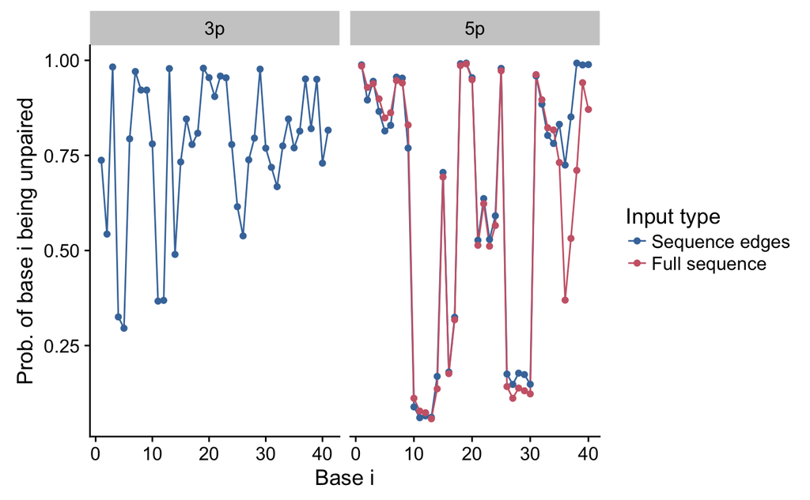

```r
unpaired_probabilities <- unpaired_probabilities %>%
  ungroup() %>%
  mutate(input = case_when(
    ibase <= 40 ~ 'gfp_puc19_full_5p',
    ibase >= (nchar(test_seq) - 40) ~ 'gfp_puc19_full_3p',
    TRUE ~ NA_character_
  )) %>%
  filter(!is.na(input)) %>%
  group_by(input) %>%
  mutate(ibase = row_number())
edge_vs_full_seq_prob <- bind_rows(nupack_outputs, unpaired_probabilities) %>%
  mutate(input = gsub('.in', '', input)) %>%
  separate(input, into = c('target', 'template', 'input_type', 'end'), sep = '_')
plot <- ggplot(edge_vs_full_seq_prob, aes(x = ibase, y = p, color = input_type))
plot+
  facet_grid( ~ end, scales = 'free_x')+
  geom_line()+
  geom_point()+
  xlab('Base i')+
  ylab('Prob. of base i being unpaired')+
  scale_color_manual(values = plot_pallets$tol2qualitative, name = "Input type",
                     labels = c('Sequence edges', 'Full sequence'))
```

```r
NA
```

It looks like **there are very changes on the base pair probabilities calculated by NUPACK when just the edges of the mega primer are used as input**. This is a very good result as it means that I don’t need to use the mega primer entire sequence for this step, reducing the running time significantly.

## 03/16/18

### Function to break the mega-primer sequence into smaller fragments

```r
split_sequence <- function(input_sequence, fragment_length) {
  string <- toupper(input_sequence)
  pattern <- paste('(?<=.{', fragment_length, '})', sep = '')
  fragments <- strsplit(input_sequence, pattern, perl=T)
}

test <- split_sequence(test_seq, 5)
test
```

### Continuing testing NUPACK with mega-primer fragments

My hypothesis is that using just the mega primer edges improves the probability of a base to be unpaired because NUPACK cannot calculate the probability of two distant bases pairing. We can check if this is the case by ploting the base pair coordinates and see if the NUPACK runs with just the edges does not contain pairs formed by two distant bases.

```r
full_seq_paired_bases <- tibble(lines = nupack_output) %>%
  filter(grepl('^\\d+\\t', lines)) %>%
  separate(lines, into = c('ibase', 'jbase', 'p'), sep = '\t') %>%
  mutate_all(as.numeric) %>%
  filter(jbase < nchar(test_seq)+1) %>%
  mutate(input = case_when(
    ibase <= 40 ~ 'gfp_puc19_full_5p',
    ibase >= (nchar(test_seq) - 40) ~ 'gfp_puc19_full_3p',
    TRUE ~ NA_character_
  )) %>%
  filter(!is.na(input))

fragments_paired_prob <- tibble(input = seq_fragments) %>%
  group_by(input) %>%
  do(
    nupack_output = run_nupack(.$input, 45, paired = T)
  ) %>%
  unnest() %>%
  mutate(
    input = basename(input),
    ibase = ifelse(input == 'gfp_puc19_frag_3p.in',
                   ibase + nchar(test_seq) - 41,
                   ibase),
    jbase = ifelse(input == 'gfp_puc19_frag_3p.in',
                   jbase + nchar(test_seq) - 41,
                   jbase)
  )
```

```
real    0m0.031s
user    0m0.024s
sys 0m0.004s

real    0m0.029s
user    0m0.021s
sys 0m0.005s
```

```r
edge_vs_full_base_pair_prob <-
  bind_rows(fragments_paired_prob, full_seq_paired_bases) %>%
  mutate(input = gsub('.in', '', input)) %>%
  separate(input, into = c('target', 'template', 'input_type', 'end'), sep = '_')
```

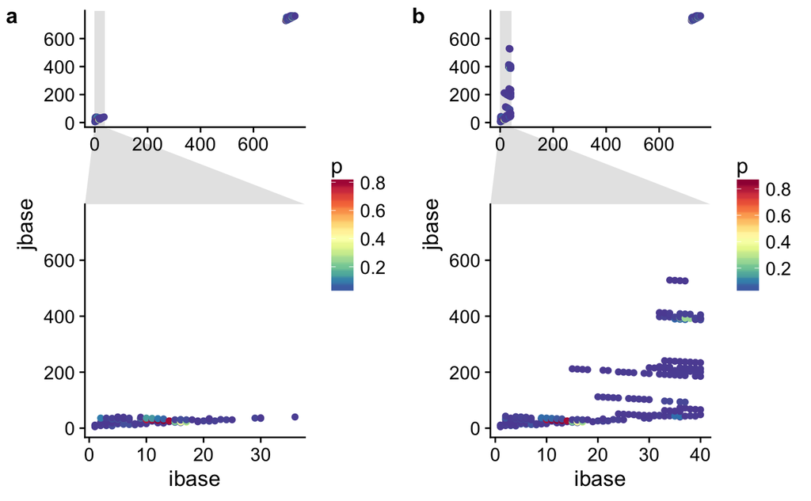

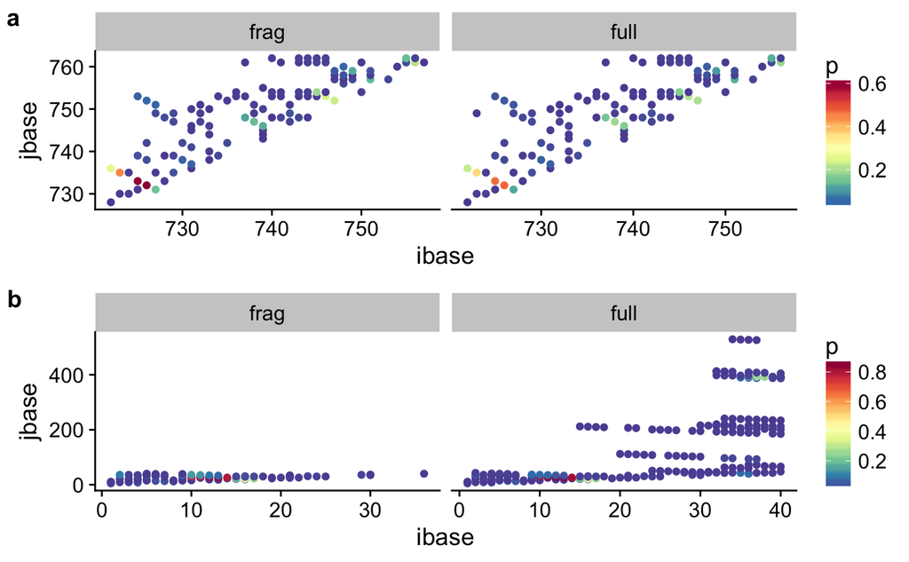

We can see that most of the changes in the base pairing probability occurs at the 5’ end of the mega-primer sequence. By using only the first 40 bp of the left end, we don’t take into consideration the probability of these bases to bind to distant bases (200-400 bp distant), increasing our unpaired probability.

### Calculating average hairpin formation probability of mega-primer edges

I need to find a way to calculate the average hairpin formation probability of the mega-primer edges and use that value as part of the primer score that will be used to rank the primers designed during the genetic algorith score.

One of the ideas I had is to calculate the average hairpin formation of the entire edge. We can write a function to calculate the average probability in a rolling window, but we need to keep track of the index of the first base of the rolling window current’s position. Let’s start with a toy dataset to figure out how to do it:

```r
df <- tibble(x = 1:10)
df %>%
  mutate(
    right_align = roll_sumr(x, 2),
    left_align = roll_suml(x, 2)
  )
```

We can write the rolling function using this information:

```r
window_size <- c(2, 3, 4, 5, 10, 20, 30)
window_probabilities <- tibble(l = window_size) %>%
  group_by(l) %>%
  do(
    cummprod = roll_prodr(unpaired_probabilities$p, n = .),
    index = unpaired_probabilities$ibase,
    input = unpaired_probabilities$input,
    ibase = unpaired_probabilities$ibase
  ) %>%
  unnest()
```

## 03/17/18

### Calculating MFE of primer edges

During the meeting I had with Imen on 03/16/18, she suggested that I calculate the probability of the primer binding the template and see if it is higher than the probability of the primers binding to each other or higher than the probability of hairpin formation. We can use NUPACk to calculate everything,

The fist one I am going to calculate is the minimum free energy secondary structure (MFE). The MFE is the secondary structure with the lowest free energy possible predicted by NUPACK. We can use this free energy value to estimate how stable the predicted primer secondary structure is and calculate the hairpin melting temperature.

#### Updating `run_nupack` function:

Add a `exec` option to specify what NUPACK tool to run. Most NUPACK tools have the same parameters:

```
pfunc [-T temperature] [-multi] [-pseudo] [-material parameters] [-dangles treatment] prefix

pairs [-T temperature] [-multi] [-pseudo] [-material parameters] [-dangles treatment] [-cutoff cutoffvalue] prefix

mfe   [-T temperature] [-multi] [-pseudo] [-material parameters] [-dangles treatment] [-degenerate] prefix
```

```r
run_nupack <- function(input_file, melting_temperature, exec, timed=FALSE,
                       multi=FALSE, paired=TRUE) {
  #What NUPACK executable to run?
  nupack_exec <- exec

  #Extracting file prefix:
  file_prefix <- gsub('.in$', '', input_file)

  #Input sequence length:
  input_seq <- read_file(input_file)

  #Running NUPACK with the input file
  if(multi) {
    nupack_command <- paste(nupack_exec, '-T', melting_temperature,
                          '-material dna', '-multi', file_prefix)
  } else {
    nupack_command <- paste(nupack_exec, '-T', melting_temperature,
                          '-material dna', file_prefix)
  }

  #Importing correct output file for selected NUPACK executable:
  if(nupack_exec == 'pairs') {
    system(nupack_command, intern = T)
    #Import output file
    output_file <- gsub('.in$', '.ppairs', input_file)
    nupack_output <- read_lines(output_file)

    #extract base pair probabilities:
    pair_probabilities <- tibble(lines = nupack_output) %>%
      filter(grepl('^\\d+\\t', lines)) %>%
      separate(lines, into = c('ibase', 'jbase', 'p'), sep = '\t') %>%
      mutate_all(as.numeric)

    if(paired) {
      pair_probabilities %>%
        filter(jbase < nchar(input_seq)+1)
    } else {
      pair_probabilities %>%
        filter(jbase == nchar(input_seq)+1)
    }
  } else if (nupack_exec == 'mfe') {
    system(nupack_command, intern = T)
    #Import output file
    output_file <- gsub('.in$', '.mfe', input_file)
    nupack_output <- read_lines(output_file)

    #extract MFE value:
    mfe <- tibble(
      input = file_prefix,
      seq = input_seq,
      mfe = nupack_output[15],
      structure = nupack_output[16]
    )
  } else if (nupack_exec == 'pfunc') {
    nupack_output <- system(nupack_command, intern = T)

    #extract dG and partion function:
    pfunc <- tibble(
      dG = nupack_output[14],
      partition_func = nupack_output[15]
    )
  }
}
```

```r
mfe <- run_nupack("notebook_data/gfp_puc19_frag_5p.in", 45, exec = 'mfe')
pfunc <- run_nupack("notebook_data/nupack_pfunc_test.in",
                    melting_temperature = 45,
                    exec = 'pfunc',
                    multi = T)

mfe
pfunc
```

## 03/22/18

### `-multi` option of `nupack` functions

```r
string1 <- 'this is  a string'
string2 <- 'this is another string'
vector_of_strings <- c('string1', 'string2')
vector_of_string_variables <- c(string1, string2)
str(string)
```

```
 chr "this is  a string"
```

```r
str(vector_of_strings)
```

```
 chr [1:2] "string1" "string2"
```

```r
str(vector_of_string_variables)
```

```
 chr [1:2] "this is  a string" "this is another string"
```

```r
typeof(string)
```

```
[1] "character"
```

```r
typeof(vector_of_strings)
```

```
[1] "character"
```

```r
typeof(vector_of_string_variables)
```

```
[1] "character"
```

```r
length(string1)
```

```
[1] 1
```

```r
length(vector_of_strings)
```

```
[1] 2
```

```r
length(vector_of_string_variables)
```

```
[1] 2
```

```r
lapply(vector_of_string_variables, print)
```

```
[1] "this is  a string"
[1] "this is another string"
[[1]]
[1] "this is  a string"

[[2]]
[1] "this is another string"
```

```r
input_seqs_test <- c(threeprime_end_seq, fiveprime_end_seq)
parse_inputs <- function(string_vector) {
  #Checking length of input vector:
  if(length(string_vector) == 1) {
    assembled_string <- string_vector
    # print(assembled_string)
  } else {
    n <- length(string_vector)
    distinct_species <- paste0(1:n, collapse = ' ')
    to_file <- c(n, string_vector, distinct_species)
    assembled_string <- paste0(to_file, collapse = "\n")

    # print(assembled_string)
  }
}
test_list <- list(threeprime_end_seq, input_seqs_test)
lapply(test_list, function(x) parse_inputs(x))
```

```
[[1]]
[1] "TGGACGAGCTGTACAAGTAAGAAAACTCACGTTAAGGGATT"

[[2]]
[1] "2\nTGGACGAGCTGTACAAGTAAGAAAACTCACGTTAAGGGATT\nGGGTCTGACGCTCAGTGGAACATGGTGAGCAAGGGCGAGG\n1 2"
```

```r
# parse_inputs(test_list)
```

```r
args <- c('pairs' , '-T', 45, '-material', 'dna', '-multi', 'prefix')
args2 <- c('pairs' , '-T', 45, '-material', 'dna', '', 'prefix')
paste0(args, collapse = ' ')
paste0(args2, collapse = ' ')
```

## 03/23/18

### Free energy-based primer score

During a lambda PCR reaction, there are three possible types of interactions involving the mega-primer and the vector template:

- Edges of the mega-primer binding to the template;
- Edges of mega-primer binding to each other (forming a hairpin);
- Self-binding on mega-primer edge (small hairpin structures)

We can calculate the free energy and the formation probability of each of these complexes and evaluate if a mega-primer is good or not based on the calculated values. Our test dataset is the mega-primer to insert the GFP gene into the pUC19 plasmid at position 1500. We need a function to evaluate the thermodynamic properties of a primer pair by computing the free energy of the different possible strucutres listed above, and then calculating a “score” for each primer in the pair. The score can be calculated by

$$Z_{i} = \Delta G_{i,t} - \Delta G_{i,i} - \Delta G_{i,j}$$
where:

- $Z_{i}$: score of primer $i$;
- $\Delta G_{i,t}$: free energy of the complex between primer $i$ and template $t$;
- $\Delta G_{i,i}$: free energy of a secondary structure in primer $i$;
- $\Delta G_{i,j}$: free energy of a dimer between primer $i$ and primer $j$;

## 03/26/18

### Calculating test primer scores

#### Function to evaluate primers

```r
evaluate_primer <- function(primer_object, template_seq) {
  #Reorganizing primer object
  primers <- primer_object %>%
    select(-type) %>%
    gather(fragment, seq, -id) %>%
    mutate(
      seq = toupper(seq),
      fragment = gsub('_seq', '', fragment)
    )

  #Melting temperature calculations
  tm <- primers %>%
    filter(grepl('annealing', fragment)) %>%
    group_by(id, fragment) %>%
    do(
      tm = melt_temperature(.$seq, 1e-07, 'Mg=1')
    ) %>%
    unnest()

  #Annealing temparature
  ta <- tm %>%
    group_by(id, fragment) %>%
    summarise(ta = min(tm) - 3) %>%
    filter(grepl('template', fragment)) %>%
    select(-fragment)
  #NUPACK calculations of complete sequences:
  nupack_results <- primers %>%
    filter(!grepl('annealing', fragment)) %>%
    left_join(ta)

  ####Creating sequence inputs for NUPACK runs:
  fw_primer <- nupack_results$seq[nupack_results$id=='forward']
  rv_primer <- nupack_results$seq[nupack_results$id=='reverse']
  tm_min <- min(nupack_results$ta)
  #Self-dimer formation free energy:
  dimers <- tribble(
    ~primer, ~complex, ~complex_type, ~dG,
    'forward', 'foward', 'sdimer', nupack_pfunc(c(fw_primer, fw_primer), tm_min),
    'reverse', 'reverse', 'sdimer', nupack_pfunc(c(rv_primer, rv_primer), tm_min),
    'forward', 'reverse', 'hdimer', nupack_pfunc(c(fw_primer, rv_primer), tm_min),
    'reverse', 'forward', 'hdimer', nupack_pfunc(c(rv_primer, fw_primer), tm_min)
  ) %>%
    unnest()
  #MFE of individual primers
  mfe <- tribble(
    ~primer, ~complex, ~complex_type, ~mfe,
    'forward', 'forward', 'hp', nupack_mfe(fw_primer, tm_min),
    'reverse', 'reverse', 'hp', nupack_mfe(rv_primer, tm_min)
  ) %>%
    unnest() %>%
    select(-structure, -base_pairs)

  # #Extracting region of template sequence around the insertion position:
  # template_seq <- inputs %>%
  #   filter(type == 'template') %>%
  #   mutate(frag = substr(seq, 1400, 1600)) %>%
  #   pull(frag)
  #Primer-template complex free energy:
  primer_template <- tribble(
    ~primer, ~complex, ~complex_type, ~dG,
    'forward', 'temp', 'ptemp', nupack_pfunc(c(fw_primer, template_seq), tm_min),
    'reverse', 'temp', 'ptemp', nupack_pfunc(c(rv_primer, template_seq), tm_min)
  ) %>%
    unnest()

  #Creating output;
  results <- bind_rows(dimers, mfe, primer_template)
  return(results)

}
```

```r
template_seq <- inputs %>%
    filter(type == 'template') %>%
    mutate(frag = substr(seq, 1400, 1600)) %>%
    pull(frag)

system.time({results <- evaluate_primer(primers, template_seq)})
```

```
|======================================================================|100% ~0 s remaining
```

```
   user  system elapsed
  5.482   0.520   5.280
```

```r
results
```

| primer | complex | complex_type | dG | partition_func |
| --- | --- | --- | --- | --- |
| forward | foward | sdimer | -1.12921504e+01 | 3.22471256382496e+07 |
| reverse | reverse | sdimer | -9.73997143e+00 | 2.99502510024321e+06 |
| forward | reverse | hdimer | -1.09033522e+01 | 1.77814594453903e+07 |
| reverse | forward | hdimer | -1.09033522e+01 | 1.77814594453903e+07 |
| forward | forward | hp | -1.886 | NA |
| reverse | reverse | hp | -0.657 | NA |
| forward | temp | ptemp | -2.73483924e+01 | 1.53027729163889e+18 |
| reverse | temp | ptemp | -3.70863228e+01 | 4.56891888302965e+24 |

#### Benchmarking `evaluate_primer` function with different fragment sizes

```r
flank_length <- c(40,50,60,70,80,90,100)
template_seq <- inputs %>%
  filter(type == 'template') %>%
  pull(seq)
fragments <- lapply(flank_length,
                    function(x) substr(template_seq, (1500-x), (1500+x)))
test_functions <- lapply(fragments,
                         function(x) call("evaluate_primer", quote(primers), x))
```

```r
library(microbenchmark)
microbenchmark(
  list = setNames(test_functions, as.character(flank_length)),
  times = 5)
```

```
|======================================================================|100% ~0 s remaining
```

```
Unit: seconds
 expr      min       lq     mean   median       uq      max neval    cld
   40 2.282277 2.286261 2.309641 2.300812 2.338975 2.339880     5 a
   50 2.471343 2.486314 2.572254 2.487842 2.524198 2.891570     5  b
   60 2.726709 2.726892 2.740319 2.737859 2.749402 2.760732     5  b
   70 3.068468 3.082212 3.090972 3.094110 3.104303 3.105766     5   c
   80 3.473709 3.482371 3.610865 3.501156 3.507494 4.089595     5    d
   90 4.062994 4.086501 4.102357 4.098781 4.115830 4.147680     5     e
  100 4.735589 4.767011 4.775281 4.769444 4.793832 4.810530     5      f
```

#### Calculating $Z_i$ score

Now that we have a function to calculate all the free energies for the different possible complexes between the primers and template, we can calculate the $Z_i$ score for each primer:

```r
primer_score <- results %>%
  select(-complex, -partition_func) %>%
  spread(complex_type, dG) %>%
  mutate_at(vars(hdimer, hp, ptemp, sdimer), funs(as.numeric(.))) %>%
  mutate(z = ptemp - (sdimer + hdimer + hp))
primer_score
```

| primer | hdimer | hp | ptemp | sdimer | z |
| --- | --- | --- | --- | --- | --- |
| forward | -10.90335 | -1.886 | -27.34839 | -11.292150 | -3.26689 |
| reverse | -10.90335 | -0.657 | -37.08632 | -9.739971 | -15.78600 |

We can interpret the $Z_i$ score as the stability of the template-primer complex, taking into consideration the binding of the pimers to each other and to themselves. **Lower $Z_i$ values indicate that the primer has a higher affinity** **to the template**, which is what we want.

## 03/27/18

### Implementing S4 Classes in `lambdaPrimeR`

#### `Template` class

```r
.TemplateClass <- setClass("TemplateClass", contains = c("data.frame"))
.TemplateClass
```

```
class generator function for class “TemplateClass” from package ‘.GlobalEnv’
function (...)
new("TemplateClass", ...)
```

```r
.TemplateClass()
```

```
Object of class "TemplateClass"
data frame with 0 columns and 0 rows
```

I need to make sure that the value supplied to the `TemplateClass` constructor is a data frame, so we need a helper function:

```r
TemplateClass <- function(df, ...) .TemplateClass(df, ...)
TemplateClass()
```

```
Error in initialize(value, ...) :
  argument "df" is missing, with no default
```

```r
df <- inputs %>%
  filter(type == "template")
template_object <- TemplateClass(df)
template_object
```

```
Object of class "TemplateClass"
```

|  | header | id | seq | type | length |
| --- | --- | --- | --- | --- | --- |
| 1 | pUC19 | pUC19 | TCGCGCGTTTCGGTGATGACGGTGAAAACCTCTGACACATGCAGCTCCCGGAGACGGTCA…… | template | 2686 |

I think the basic slots on the `TemplateClass` class should be:

- `path`: a string containing the path to the input fasta file;
- `data`: data frame with the sequence information;

```r
.TemplateClass <- setClass("TemplateClass",
                           contains = c("data.frame"))
.TemplateClass
```

```
class generator function for class “TemplateClass” from package ‘.GlobalEnv’
function (...)
new("TemplateClass", ...)
```

We can create two subclasses from `TemplateClass` that will represent each different type of templates (target and vectors):

```r
.TargetClass <- setClass("TargetClass",
                         contains = c("TemplateClass"))
.VectorClass <- setClass("VectorClass",
                         contains = c("TemplateClass"))
.TargetClass
```

```
class generator function for class “TargetClass” from package ‘.GlobalEnv’
function (...)
new("TargetClass", ...)
```

```r
.VectorClass
```

```
class generator function for class “VectorClass” from package ‘.GlobalEnv’
function (...)
new("VectorClass", ...)
```

## 03/29/18

### Updating `read_sequence` function to work with the S4 class system

We first need to write a helper function to create new `TargetClass` and `VectorClass` objects from an input fata frame:

```r
TargetClass <- function(df, ...) .TargetClass(df, ...)
VectorClass <- function(df, ...) .VectorClass(df, ...)
```

We can change the `read_sequence` function to read a fasta file and assign the input to a specific class depending on the value of the `input_type` argument.

```r
read_sequences <- function(file, input_type = c('target', 'vector'),
                           id_field = NULL, separator = NULL) {

  #Checking input type:
  type <- match.arg(input_type)

  #Reading fasta file into a column:
  raw <- tibble(text = read_file(file))

  #Converting the raw text column into the correct format:
  df <- raw %>%
    separate_rows(text, sep = '\n>') %>%
    separate(text, into = c('header', 'seq'), sep = '\n', extra = 'merge') %>%
    mutate(
      path = file,
      type = input_type,
      seq = stringr::str_replace_all(seq, '\n', ''),
      header = stringr::str_replace(header, '>', ''),
      length = nchar(seq)
    )

  #Checking if optional parameters were passed
  if(is.null(id_field)) {
    id_field <- 'name'
  }
  if(is.null(separator)) {
    separator <- '\\|'
  }

  #Creating sequence id from seq header
  df <- df %>%
    separate(header, into = id_field, remove = F, extra = 'drop', sep = separator)

  #Checking what type of input was provided and creating appropriate class obj.:
  # object <- switch (input_type,
  #   'target' = TargetClass(df),
  #   'vector' = VectorClass(df)
  # )

  return(df)

  #Appending new input to input dataframe if input_df object was provided:
  # if(!is.null(input_df)) {
  #   input_df <- bind_rows(input_df, df)
  # } else {
  #   df
  # }
}
```

```r
target_object <- read_sequences(target, input_type = 'target')
```

```
Error in empty_file(file) : object 'target' not found
```

## 03/30/18

### Testing primer score function with variations of test primer

#### Increasing lengths of vector and target annealing regions

In order to test how the length of a primer affects the $Z_i$ score, I’ll use the `get_overlaps` function to extract the vector and target annealing regions from the input sequences with increasing lengths:

```r
annealing_region_lengths <- c(10:30)
overlaps <- lapply(annealing_region_lengths,
                   function(x) get_overlaps(inputs, position = 1500,
                                            vector_ovlp_length = x,
                                            target_ovlp_length = x))

var_length_primers <- lapply(overlaps, function(x) create_primer_pair(x))
```

```r
primer_eval <- lapply(var_length_primers,
                      function(x) evaluate_primer(x, template_seq))
```

```r
names(primer_eval) <- annealing_region_lengths
primer_eval_df <- bind_rows(primer_eval, .id = 'length') %>%
  mutate(
    length = as.numeric(length),
    dG = as.numeric(dG)
  )

calculate_primer_score <- function(primer_eval_df) {
  score <- primer_eval_df %>%
  select(-complex, -partition_func) %>%
  spread(complex_type, dG) %>%
  mutate_at(vars(hdimer, hp, ptemp, sdimer), funs(as.numeric(.))) %>%
  mutate(z = ptemp - (sdimer + hdimer + hp))
}

primer_scores <- primer_eval_df %>%
  group_by(length) %>%
  do(
    calculate_primer_score(.)
  )
```

```r
primer_scores %>%
  ggplot(., aes(x=length, y=z)) +
  facet_grid(~ primer) +
  geom_point()
```

```r
primer_eval_df %>%
  ggplot(., aes(x=length, y=dG, color = primer)) +
  facet_grid(~complex_type) +
  geom_point()
```

#### Primers with variation only on the length of the vector-annealing region

We first need to update the `get_overlaps` function to allow different lenghts for the different overlapping regions:

```r
get_overlaps <- function(sequence_inputs, position=NULL,
                         vector_ovlp_length=NULL,
                         target_ovlp_length=NULL) {
  #Initialize empty overlap object
  overlaps <- tibble(
    id = character(),
    type = character(),
    origin = character(),
    seq = character()
  )

  #Function to find overlaps on each input type:
  find_overlaps <- function(data) {
    #Checking what type of input was passed:
    if(data$type == 'template') {
      length <- vector_ovlp_length
      #Using default overlap length of 20 if not provided:
      overlap_length <- ifelse(is.null(length), 20, length)
      #Extracting overlaps
      overlap_left <- substr(data$seq, (position-overlap_length), position)
      overlap_right <- substr(data$seq, (position+1), (overlap_length+position+1))
      #Populating overlap object:
      overlaps <- overlaps %>%
        add_row(id = 'left', type = 'overlap', origin = 'template', seq = overlap_left) %>%
        add_row(id = 'right', type = 'overlap', origin = 'template', seq = overlap_right)
    } else {
      #Using default overlap length of 15 if not provided:
      length <- target_ovlp_length
      overlap_length <- ifelse(is.null(length), 15, length)
      #Extracting overlaps
      overlap_left <- substr(data$seq, 1, overlap_length)
      overlap_right <- substr(data$seq, data$length-overlap_length, data$length)
      #Populating overlap object:
      overlaps <- overlaps %>%
        add_row(id = 'left', type = 'overlap', origin = 'target', seq = overlap_left) %>%
        add_row(id = 'right', type = 'overlap', origin = 'target', seq = overlap_right)
    }
  }

  #Extracting overlaps
  sequence_inputs %>%
    group_by(type) %>%
    do(find_overlaps(.)) %>%
    ungroup()
}
```

Let’s recalculate the primer scores with just the vector-annealing region increasing in size:

```r
overlaps <- lapply(annealing_region_lengths,
                   function(x) get_overlaps(inputs, position = 1500,
                                            vector_ovlp_length = x))
var_length_primers <- lapply(overlaps, create_primer_pair)
varying_vector_reg <- lapply(var_length_primers,
                      function(x) evaluate_primer(x, template_seq))
```

```r
names(varying_vector_reg) <- annealing_region_lengths
vector_reg_primer_eval_df <- bind_rows(varying_vector_reg, .id = 'length') %>%
  mutate(
    length = as.numeric(length),
    dG = as.numeric(dG)
  )

vector_reg_primer_scores <- vector_reg_primer_eval_df %>%
  group_by(length) %>%
  do(
    calculate_primer_score(.)
  )
```

```r
vector_reg_primer_scores %>%
  ggplot(., aes(x=length, y=z)) +
  facet_grid(~ primer) +
  geom_point()

vector_reg_primer_eval_df %>%
  ggplot(., aes(x=length, y=dG, color = primer)) +
  facet_grid(~complex_type) +
  geom_point()
```

```r
scores_merged <- bind_rows(vector_reg_primer_scores, primer_scores, .id = 'id') %>%
  mutate(id = ifelse(id == 1, 'increase_vector', 'increase_both'))

thermodynamics_merged <- bind_rows(vector_reg_primer_eval_df, primer_eval_df,
                                   .id = 'id') %>%
    mutate(id = ifelse(id == 1, 'increase_vector', 'increase_both'))

scores_merged %>%
  ggplot(., aes(x=length, y=z, color = id)) +
  facet_grid(~primer)+
  geom_point()+
  plot_theme

thermodynamics_merged %>%
  ggplot(., aes(x=length, y=dG, color = id)) +
  facet_grid(primer~complex_type) +
  geom_point()+
  plot_theme
```

#### Benchmarking `evaluate_primers` function with primer with inscreasing length

```r
library(microbenchmark)
test_functions <- lapply(var_length_primers,
                         function(x) call("evaluate_primer", x, quote(template_seq)))

microbenchmark(
  list = setNames(test_functions, as.character(annealing_region_lengths)),
  times = 1)
```

## 03/31/18

### Object validation function for `TemplateClass`

In order to make sure that the `TemplateClass` will have the correct fields and data format, we need to write a validation function that will check if the input is a data frame with the minimum required columns. We need at least the following columns for each template input:

- `path`: path to input file;
- `header`: complete string of the sequence’s FASTA header;
- `name`: parsed fragment of the sequence header that will be used as the template name;
- `sequence`: template sequence;
- `length`: sequence length;
- `id`: internal numeric id that will group a set of `Target`, `VectorClass` and `Primer` objects;

Let’s first find out how to test the type of a column against a defined column type:

```r
required_columns <- tribble(
  ~cols, ~req_class,
  'path','character',
  'header','character',
  'id','character',
  'seq','character',
  'type','character',
  'length','integer'
)
column_types <- as.data.frame(lapply(df, class)) %>%
  gather(cols, test_class)
```

```
attributes are not identical across measure variables;
they will be dropped
```

```r
discrepancies <- full_join(required_columns, column_types) %>%
  mutate(test = ifelse(req_class == test_class, TRUE, FALSE)) %>%
  do(
    msg = case_when(
      is.na(.$test) ~ paste("Missing required column:", .$cols),
      !(.$test) ~ paste("Column ", .$cols, " type is incorrect. ",
                        "Required type is ", .$req_class, ", current type is ",
                        .$test_class, ".", sep = ''),
      (.$test) ~ NA_character_
    )
  ) %>%
  unnest() %>%
  filter(!is.na(msg))
```

We can now write a validation function for out `TemplateClass`:

```r
validate_template <- function(object) {
  errors <- NULL
  #Checking if object is data frame:
  if(!is.data.frame(object)) {
      errors <- c(errors, "Input was not a data frame")
      return(FALSE)
  }

  #Checking if required columns are present with the correct format:
  required_columns <- tribble(
    ~cols, ~req_class,
    'path','character',
    'header','character',
    'name','character',
    'seq','character',
    'type','character',
    'length','numeric'
  )
  #Creating data frame with column types:
  column_types <- as.data.frame(lapply(df, class)) %>%
    gather(cols, test_class)

  #Checking column types against required columns:
  discrepancies <- full_join(required_columns, column_types) %>%
    mutate(test = ifelse(req_class == test_class, TRUE, FALSE)) %>%
    do(
      msg = case_when(
        is.na(.$test) ~ paste("Missing required column: ", .$cols, ";\n", sep = ''),
        !(.$test) ~ paste("Column ", .$cols, " type is incorrect: ",
                          "required type is ", .$req_class, ", current type is ",
                          .$test_class, ";\n", sep = ''),
        (.$test) ~ NA_character_
      )
    ) %>%
    unnest() %>%
    filter(!is.na(msg))

  errors <- c(errors, discrepancies$msg)
  return(errors)
}
```

Let’s add this validation function to the `TargetClass` constructor function:

```r
TargetClass <- function(df, ...) {
  #Calling validation function:
  errors <- validate_template(df)

  if(length(errors) != 0) {
    stop(errors)


    # return(FALSE)
  }
  .TargetClass(df, ...)
}
df <- inputs %>%
  filter(type == "template")
```

```
Error in eval(lhs, parent, parent) : object 'inputs' not found
```

### Adding method to get overlaps for both `Target` and `VectorClass`

#Create generic function and methods for `get_annealing_regions`

```r
setGeneric("get_annealing_regions",
           function(template, position = NULL, min_length = NULL,
                    max_length = NULL, ...) {
             standardGeneric("get_annealing_regions")
})
```

```
[1] "get_annealing_regions"
```

Let’s create methods for `get_annealing_regions` that will extract a different region from depending on the type of template:

```r
setMethod("get_annealing_regions",
  signature = "TargetClass",
  function(template, min_length = NULL, max_length = NULL) {
    #Using minimum allowed length as the length of the annealing region;
    #otherwise use the default of 15 bp.
    length <- ifelse(is.null(min_length), 15, min_length)

    #Saving sequence slot from template class in a variable:
    seq <- template@seq
    seq_length <- template@length

    #When extracting the annealing regions from the target sequence, we need to
    #get the 5' and 3' ends of the gene sequence:
    #Extracting overlaps
    target_annealing_left <- substr(seq, 1, length)
    target_annealing_right <- substr(seq, seq_length-length, length)

    #Adding new information to Target object:
    # annealing_regions <- tibble(
    #   min_length = integer(),
    #   max_length = integer(),
    #   annealing_reg_left_beg = integer(),
    #   annealing_reg_left_end = integer(),
    #   annealing_reg_right_beg = integer(),
    #   annealing_reg_right_end = integer(),
    #   annealing_reg_left_seq = character(),
    #   annealing_reg_right_seq = character()
    # )

    annealing_regions <- tibble(
      min_length = min_length,
      max_length = max_length,
      annealing_reg_left_beg = 1,
      annealing_reg_left_end = length,
      annealing_reg_right_beg = seq_length - length,
      annealing_reg_right_end = seq_length,
      annealing_reg_left_seq = target_annealing_left,
      annealing_reg_right_seq = target_annealing_right
    )

    template <- bind_cols(template, annealing_regions)
  }
)
```

```
[1] "get_annealing_regions"
```

```r
target_object <- TargetClass(target_df)
```

[output not shown]